# Envisioning the next offensive football play in the AFC North Division

#### Luis Paz

[figure not shown]

## Introduction

American football is one of the most popular sports in the world. The well known sport holds one of the four major professional sports leagues in North America. The National Football League (NFL) is a professional American football league, consisting of 32 teams divided into two conferences, the American Football Conference (AFC) and the National Football Conference (NFC).

Each NFL team participates in a 17-week regular season which consists of 16 games between September and December. At the conclusion of the regular season, six teams from each conference participate in a single-elimination tournament, culminating in the Super Bowl. The immense popularity of the sport can be demonstrated with the number of viewers in this championship game, regularly reaching over 100 million.

The purpose of this tutorial will be to analyze NFL data from 2009-2017, eventually creating a model to predict the next offensive play. This would be extremely valuable to defensive coordinators, team personnel responsible for calling defensive plays. Knowing what type of play the opponent's offense will play next would prove especially useful in defending said play.

## Getting Started

In the sport of football, when a team has possession of the ball, their objective is to move the ball forward into the end zone, or, to move the ball a minimum of ten yards in four attempts (called downs, the first of each series being 'first down' and then 'second down', etc.). Teams can accomplish this either through passing or rushing (running with the football). The terms "rushing" and "running" will be used interchangeably in this analysis.

For a complete and official list of football rules in the NFL, click [here](https://operations.nfl.com/the-rules/2018-nfl-rulebook/)

### Importing Required Libraries

The following imports are all required to complete this tutorial.

```python
import pandas as pd
import numpy as np

import matplotlib.pyplot as plt

from sklearn.model_selection import train_test_split
from sklearn.tree import DecisionTreeClassifier
from sklearn.ensemble import RandomForestClassifier
from sklearn.linear_model import LogisticRegression
from sklearn.neighbors import KNeighborsClassifier
from sklearn.model_selection import cross_val_score
from sklearn.metrics import mean_squared_error
from sklearn.metrics import roc_curve, auc
```

[Max Horowitz](https://www.kaggle.com/maxhorowitz), founder of the Carnegie Mellon Sports Analytics Club, developed nflscrapR to scrape data from NFL.com, along with all of the statistics generated by the expected points and win probability models. Other researchers involved in this process include Ron Yurko and and Sam Ventura.

The data was obtained from [here](https://github.com/ryurko/nflscrapR-data/tree/master/legacy_data).

```python
play_df = pd.read_csv('NFLPlaybyPlay2009-2017(v4).csv')
(rows, columns) = play_df.shape
play_df.head()
```

|  | Date | GameID | Drive | qtr | down | time | TimeUnder | TimeSecs | PlayTimeDiff | SideofField | ... | yacEPA | Home_WP_pre | Away_WP_pre | Home_WP_post | Away_WP_post | Win_Prob | WPA | airWPA | yacWPA | Season |
| --- | --- | --- | --- | --- | --- | --- | --- | --- | --- | --- | --- | --- | --- | --- | --- | --- | --- | --- | --- | --- | --- |
| 0 | 2009-09-10 | 2009091000 | 1 | 1 | NaN | 15:00 | 15 | 3600.0 | 0.0 | TEN | ... | NaN | 0.485675 | 0.514325 | 0.546433 | 0.453567 | 0.485675 | 0.060758 | NaN | NaN | 2009 |
| 1 | 2009-09-10 | 2009091000 | 1 | 1 | 1.0 | 14:53 | 15 | 3593.0 | 7.0 | PIT | ... | 1.146076 | 0.546433 | 0.453567 | 0.551088 | 0.448912 | 0.546433 | 0.004655 | -0.032244 | 0.036899 | 2009 |
| 2 | 2009-09-10 | 2009091000 | 1 | 1 | 2.0 | 14:16 | 15 | 3556.0 | 37.0 | PIT | ... | NaN | 0.551088 | 0.448912 | 0.510793 | 0.489207 | 0.551088 | -0.040295 | NaN | NaN | 2009 |
| 3 | 2009-09-10 | 2009091000 | 1 | 1 | 3.0 | 13:35 | 14 | 3515.0 | 41.0 | PIT | ... | -5.031425 | 0.510793 | 0.489207 | 0.461217 | 0.538783 | 0.510793 | -0.049576 | 0.106663 | -0.156239 | 2009 |
| 4 | 2009-09-10 | 2009091000 | 1 | 1 | 4.0 | 13:27 | 14 | 3507.0 | 8.0 | PIT | ... | NaN | 0.461217 | 0.538783 | 0.558929 | 0.441071 | 0.461217 | 0.097712 | NaN | NaN | 2009 |

5 rows × 102 columns

```python
print("Rows: ", rows, " Columns: ", columns)
```

```
Rows:  407688  Columns:  102
```

We can see we have a DataFrame with 407,688 rows and 102 columns. We will not be using all the rows or columns in this tutorial.

```python
# Generating basic statistics for the columns of the play_df DataFrame
play_df.describe()
```

|  | GameID | Drive | qtr | down | TimeUnder | TimeSecs | PlayTimeDiff | yrdln | yrdline100 | ydstogo | ... | yacEPA | Home_WP_pre | Away_WP_pre | Home_WP_post | Away_WP_post | Win_Prob | WPA | airWPA | yacWPA | Season |
| --- | --- | --- | --- | --- | --- | --- | --- | --- | --- | --- | --- | --- | --- | --- | --- | --- | --- | --- | --- | --- | --- |
| count | 4.076880e+05 | 407688.000000 | 407688.000000 | 346534.000000 | 407688.000000 | 407464.000000 | 407244.000000 | 406848.000000 | 406848.000000 | 407688.000000 | ... | 159190.000000 | 382734.000000 | 382734.000000 | 381101.000000 | 381101.000000 | 382679.000000 | 402147.000000 | 159187.000000 | 158926.000000 | 407688.000000 |
| mean | 2.013158e+09 | 12.316158 | 2.577412 | 2.002476 | 7.374200 | 1695.268944 | 20.576762 | 28.488327 | 48.644081 | 7.309403 | ... | -0.386086 | 0.534488 | 0.465965 | 0.534791 | 0.465613 | 0.501320 | 0.002099 | 0.015135 | -0.010480 | 2013.018985 |
| std | 2.572839e+06 | 7.149527 | 1.129750 | 1.006353 | 4.642388 | 1062.801012 | 17.969326 | 12.946471 | 25.070416 | 4.869987 | ... | 1.972715 | 0.285574 | 0.285629 | 0.287818 | 0.287867 | 0.287445 | 0.045363 | 0.056490 | 0.068139 | 2.576962 |
| min | 2.009091e+09 | 1.000000 | 1.000000 | 1.000000 | 0.000000 | -900.000000 | 0.000000 | 1.000000 | 1.000000 | 0.000000 | ... | -14.000000 | 0.000000 | 0.000000 | 0.000000 | 0.000000 | 0.000000 | -0.997214 | -0.999881 | -0.986673 | 2009.000000 |
| 25% | 2.011101e+09 | 6.000000 | 2.000000 | 1.000000 | 3.000000 | 778.000000 | 5.000000 | 20.000000 | 30.000000 | 3.000000 | ... | -0.961115 | 0.325123 | 0.231411 | 0.321701 | 0.227694 | 0.276472 | -0.014728 | -0.011518 | -0.018683 | 2011.000000 |
| 50% | 2.013111e+09 | 12.000000 | 3.000000 | 2.000000 | 7.000000 | 1800.000000 | 17.000000 | 30.000000 | 49.000000 | 9.000000 | ... | 0.000000 | 0.531274 | 0.469052 | 0.533609 | 0.466670 | 0.504470 | 0.000000 | 0.003441 | 0.000000 | 2013.000000 |
| 75% | 2.015121e+09 | 18.000000 | 4.000000 | 3.000000 | 11.000000 | 2585.000000 | 37.000000 | 39.000000 | 70.000000 | 10.000000 | ... | 0.485508 | 0.769232 | 0.675530 | 0.772882 | 0.678833 | 0.725477 | 0.014684 | 0.035792 | 0.011431 | 2015.000000 |
| max | 2.017123e+09 | 35.000000 | 5.000000 | 4.000000 | 15.000000 | 3600.000000 | 943.000000 | 50.000000 | 99.000000 | 50.000000 | ... | 9.559834 | 1.000000 | 1.000000 | 1.000000 | 1.000000 | 1.000000 | 0.994848 | 0.994848 | 1.000000 | 2017.000000 |

8 rows × 64 columns

```python
play_df.info()
```

```
<class 'pandas.core.frame.DataFrame'>
RangeIndex: 407688 entries, 0 to 407687
Columns: 102 entries, Date to Season
dtypes: float64(33), int64(31), object(38)
memory usage: 317.3+ MB
```

With the combination of `play_df.describe()` and `play_df.info()`, we find that the data is mostly complete. We will have to deal with missing data in order to provide accurate results. DataFrame columns will also need to deal with mixed data types.

The primary columns we will be interested in are as follows:

- **GameID**: The ID of the specified game, a combination of the specific game date and current season
- **Drive**: Drive number
  - A drive is a series of plays when the offense has possession of the football, until it punts or scores and the other team gets possession
- **PlayType**: The type of play that occured
  - Potential values are:
    - **Run**
    - **Pass**
    - Kickoff
    - Punt
    - Sack
    - Field Goal
    - Extra Point
    - Quarter End
    - Two Minute Warning
    - Half End
    - End of Game
    - No Play
    - QB Kneel
    - Spike
    - Timeout
- **PassAttempt**: Binary value; 1 if a pass was attempted otherwise 0
- **RushAttempt**: Binary value; 1 if a run was attempted otherwise 0
- **qtr**: The current quarter
  - An NFL game has four quarters of 15 minutes in regulation, with an additional quarter (5) of overtime if necessary
- **Down**: Down of the given play
  - Values vary from 1 to 4
- **time**: Time at start of play (in minutes:seconds)
- **TimeUnder**: Time remaining in half (in minutes)
- **TimeSecs**: Time remaining in game (in seconds)
- **PlayTimeDiff**: Time difference (in seconds) between the last play and the current play
- **posteam**: The team with possession of the football; team currently on offense
- **DefensiveTeam**: The defensive team on the play
  - For punts, the receiving team is on defense
  - For kickoffs, the receiving team is on offense
- **SideofField**: The side of the field that the line of scrimmage is on
- **PosTeamScore**: The score of the possession team (offensive team)
- **DefTeamScore**: The score of the defensive team
- **yrdline100**: Distance to opponent's end zone, ranges from 1-99
  - 1-49 corresponds to the opponent's side of the field
  - 50-99 corresponds to the team's (with possession) side of field
- **Yards.Gained**: Amount of yards gained on the play
- **ydstogo**: Amount of yards remaining for a first down
- **GoalToGo**: Binary value; 1 if the play is in a goal down situation otherwise 0
- **No_Score_Prob**: Probability of no score occurring within the half
- **Opp_Safety_Prob**: Probability of the defensive team scoring a safety next
- **Opp_Field_Goal_Prob**: Probability of the defensive team scoring a field goal next
- **Opp_Touchdown_Prob**: Probability of the defensive team scoring a touchdown next
- **Win_Prob** - The win probability added for team with possession
- **ExpPts**: The expected points for the possession team at the start of the play
- **Season**: The season in which the game was played in

## Exploratory Data Analysis

```python
# Constructing DataFrame with only columns deemed interesting
play_attributes = ['GameID','qtr','TimeSecs','yrdline100','ydstogo','Drive','down','PlayType','PassAttempt',
                   'RushAttempt','Yards.Gained','posteam','DefensiveTeam','PosTeamScore','DefTeamScore','Season']
plays = play_df[play_attributes]
plays.head()
```

|  | GameID | qtr | TimeSecs | yrdline100 | ydstogo | Drive | down | PlayType | PassAttempt | RushAttempt | Yards.Gained | posteam | DefensiveTeam | PosTeamScore | DefTeamScore | Season |
| --- | --- | --- | --- | --- | --- | --- | --- | --- | --- | --- | --- | --- | --- | --- | --- | --- |
| 0 | 2009091000 | 1 | 3600.0 | 30.0 | 0 | 1 | NaN | Kickoff | 0 | 0 | 39 | PIT | TEN | 0.0 | 0.0 | 2009 |
| 1 | 2009091000 | 1 | 3593.0 | 58.0 | 10 | 1 | 1.0 | Pass | 1 | 0 | 5 | PIT | TEN | 0.0 | 0.0 | 2009 |
| 2 | 2009091000 | 1 | 3556.0 | 53.0 | 5 | 1 | 2.0 | Run | 0 | 1 | -3 | PIT | TEN | 0.0 | 0.0 | 2009 |
| 3 | 2009091000 | 1 | 3515.0 | 56.0 | 8 | 1 | 3.0 | Pass | 1 | 0 | 0 | PIT | TEN | 0.0 | 0.0 | 2009 |
| 4 | 2009091000 | 1 | 3507.0 | 56.0 | 8 | 1 | 4.0 | Punt | 0 | 0 | 0 | PIT | TEN | 0.0 | 0.0 | 2009 |

```python
# Removing observations with a missing 'PlayType' or a play that ended up not counting (penalties, etc.)
plays = plays[(plays.PlayType.notna()) &
              (plays.PlayType != 'No Play')]
              #(plays.PlayType != 'Kickoff') &
              #(plays.PlayType != 'Extra Point')]

# Renaming 'posteam' column as 'Team'
plays = plays.rename(columns = {'posteam':'Team'})
plays.head()
```

|  | GameID | qtr | TimeSecs | yrdline100 | ydstogo | Drive | down | PlayType | PassAttempt | RushAttempt | Yards.Gained | Team | DefensiveTeam | PosTeamScore | DefTeamScore | Season |
| --- | --- | --- | --- | --- | --- | --- | --- | --- | --- | --- | --- | --- | --- | --- | --- | --- |
| 0 | 2009091000 | 1 | 3600.0 | 30.0 | 0 | 1 | NaN | Kickoff | 0 | 0 | 39 | PIT | TEN | 0.0 | 0.0 | 2009 |
| 1 | 2009091000 | 1 | 3593.0 | 58.0 | 10 | 1 | 1.0 | Pass | 1 | 0 | 5 | PIT | TEN | 0.0 | 0.0 | 2009 |
| 2 | 2009091000 | 1 | 3556.0 | 53.0 | 5 | 1 | 2.0 | Run | 0 | 1 | -3 | PIT | TEN | 0.0 | 0.0 | 2009 |
| 3 | 2009091000 | 1 | 3515.0 | 56.0 | 8 | 1 | 3.0 | Pass | 1 | 0 | 0 | PIT | TEN | 0.0 | 0.0 | 2009 |
| 4 | 2009091000 | 1 | 3507.0 | 56.0 | 8 | 1 | 4.0 | Punt | 0 | 0 | 0 | PIT | TEN | 0.0 | 0.0 | 2009 |

Note: We did not remove observations where the 'PlayType' was considered to be 'Kickoff', 'Extra Point', etc. as the 'PassAttempt' and 'RushAttempt' values are already set at 0 and 0, respectively.

We will construct a bar plot displaying the number of PassAttempts and RushAttempts distributed by quarter.

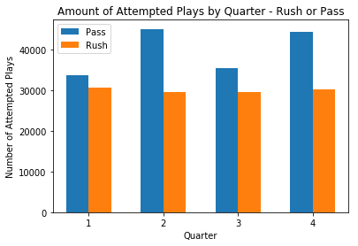

```python
# Removing plays that occur outside of regulation, a fifth quarter corresponds to a play occuring in overtime
regulation_plays = plays[plays.qtr != 5]

# Creating a dataframe with the sum of PassAttempts and RushAttempts grouped by quarter
run_pass_data = regulation_plays.groupby(['qtr'])['PassAttempt','RushAttempt'].sum()

num_quarters = 4
pass_quarter = np.array(run_pass_data["PassAttempt"])
run_quarter = np.array(run_pass_data["RushAttempt"])

ind = np.arange(num_quarters)
width = 0.30

# Creating a bar chart displaying both pass attempts and rush attempts
plt.bar(ind, pass_quarter, width, label='Pass')
plt.bar(ind + width, run_quarter, width, label='Rush')

# Labeling the bar chart
plt.ylabel('Number of Attempted Plays')
plt.xlabel('Quarter')
plt.title('Amount of Attempted Plays by Quarter - Rush or Pass')
plt.xticks(ind + width / 2, ('1', '2', '3', '4'))
plt.legend()

plt.show()
```

This bar chart helps visualize the variation in pass attempts and rush attempts by quarter. In each quarter, the number of passing attempts is greater than the number of rushing attempts, suggesting a league-wide preference to passing. Some changes that have aided this preference include rule modifications limiting the ways a defensive back can defend a wide receiver and the enforcement of rules protecting the quarterback. Additional information regarding the league's shift to a passing league and its consequences to the game of football can be found [here](http://www.nfl.com/news/story/09000d5d82a44e69/article/passing-league-explaining-the-nfls-aerial-evolution).

A major distinction that can be also be seen is the increase in passing attempts in the 2$^{nd}$ and 4$^{th}$ quarters. In contrast, the rush plays remain fairly stagnant. This is most likely a result of teams trying to score quickly before halftime (2$^{nd}$ quarter) or to win the game before time runs out (4$^{th}$ quarter).

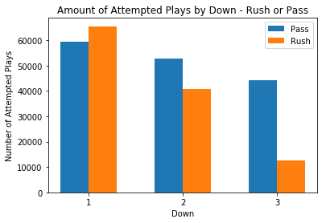

```python
# Removing plays that occur at 4th down, a down nearly always resulting in a punt
plays_down = plays[plays.down <= 3]

# Creating a DataFrame with the sum of PassAttempts and RushAttempts grouped by down
run_pass_down_data = plays_down.groupby(['down'])['PassAttempt','RushAttempt'].sum()

num_downs = 3
pass_down = np.array(run_pass_down_data["PassAttempt"])
run_down = np.array(run_pass_down_data["RushAttempt"])

ind = np.arange(num_downs)
width = 0.30
# Creating a bar chart displaying both pass attempts and rush attempts
plt.bar(ind, pass_down, width, label='Pass')
plt.bar(ind + width, run_down, width, label='Rush')

# Labeling the bar chart
plt.ylabel('Number of Attempted Plays')
plt.xlabel('Down')
plt.title('Amount of Attempted Plays by Down - Rush or Pass')
plt.xticks(ind + width / 2, ('1', '2', '3'))
plt.legend()

plt.show()
```

This bar chart displays the disparity in the type of attempted play when taking into account the specific down. This visualization demonstrates how later downs correspond in a greater frequency of attempted passes. The number of rush plays decrease in later downs.

We will now create line plots for teams in the AFC North, a prominent division in the AFC. The lineplot will demonstrate the number of Pass Attempts and Rush Attempts over the 2009-2017 NFL regular season games for the Baltimore Ravens ('BAL'), Cincinnati Bengals ('CIN'), Cleveland Browns ('CLE'), Pittsburgh Steelers ('PIT').

```python
# Dictionary will provide team colors for line plots
color_dict = {"BAL": ["purple", "black"], "CIN": ["orange", "black"], "CLE": ["darkorange", "saddlebrown"],
              "PIT": ["gold", "black"] }
```

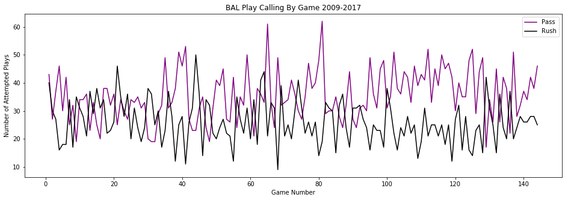

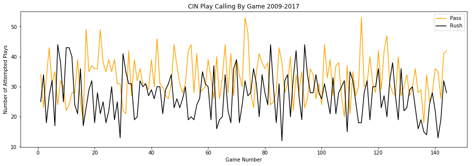

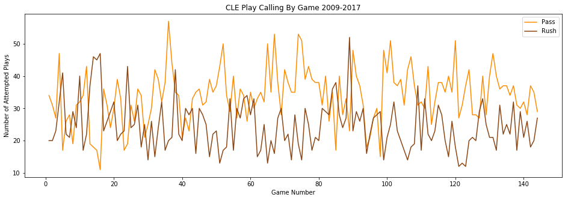

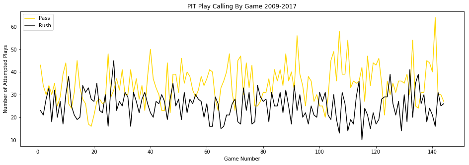

```python
# Removing plays that occur at 4th down, a down nearly always resulting in a punt
plays_down = plays[plays.down <= 3]

# Team names for the four teams in the AFC North division
afc_north = ["BAL", "CIN", "CLE", "PIT"]

for i,team in enumerate(afc_north):
    # Setting the figure size
    plt.rcParams["figure.figsize"] = [16,5]

    # Acquiring DataFrame for current AFC North team
    play_team_df = plays_down.loc[plays_down['Team'] == team]
    run_pass_df = play_team_df.groupby(['Season','GameID'])['PassAttempt','RushAttempt'].sum()

    # Game Number ranges from the first game of the 2009 season to the last game of the 2017 season
    ind = np.arange(1, len(run_pass_df.index) + 1)
    run_pass_df["index"] = ind

    # Plotting the number of PassAttempts and RushAttempts
    passing = plt.plot(run_pass_df['index'],run_pass_df['PassAttempt'],color = color_dict.get(team)[0],label = "Pass")
    rushing = plt.plot(run_pass_df['index'],run_pass_df['RushAttempt'],color = color_dict.get(team)[1],label = "Rush")

    # Labeling the line plot
    plt.ylabel("Number of Attempted Plays")
    plt.xlabel("Game Number")
    plt.title(team + " Play Calling By Game 2009-2017")
    plt.legend()
    plt.show()
```

The above line plots demonstrate how the league-wide preference to passing is no exception to the AFC North. In regards to the approximately last 30 games, all four teams experienced a period in which Pass Attempts greatly outnumbered or equaled the corresponding number of Rush Attempts.

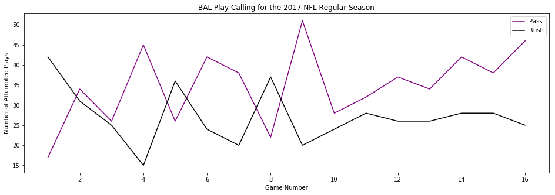

```
BAL Means
Mean Pass Attempts:  34.875
Mean Rush Attempts:  27.1875
```

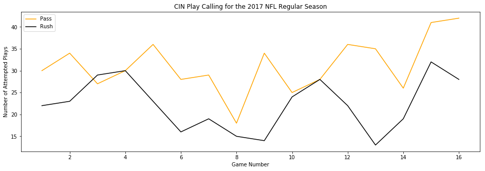

```
CIN Means
Mean Pass Attempts:  31.1875
Mean Rush Attempts:  22.3125
```

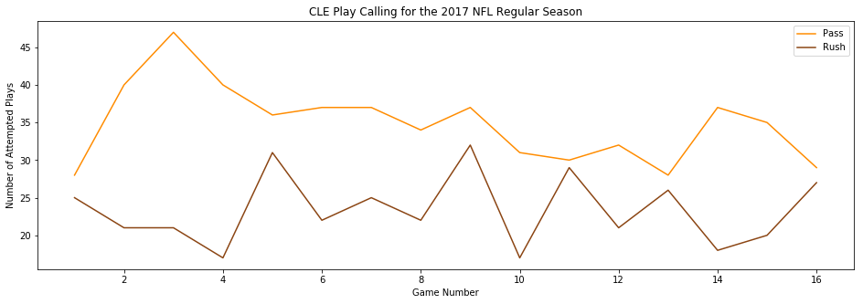

```
CLE Means
Mean Pass Attempts:  34.875
Mean Rush Attempts:  23.375
```

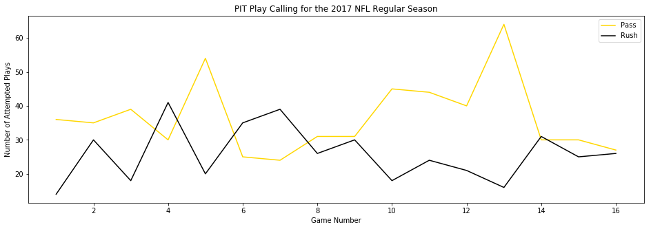

```
PIT Means
Mean Pass Attempts:  36.5625
Mean Rush Attempts:  25.875
```

```python
# Removing plays that occur at 4th down, a down nearly always resulting in a punt
plays_down = plays[plays.down <= 3]

# Team names for the four teams in the AFC North division
afc_north = ["BAL", "CIN", "CLE", "PIT"]

for i,team in enumerate(afc_north):
    # Acquiring DataFrame for current AFC North team
    play_team_df = plays_down.loc[plays_down['Team'] == team]
    play_team_df = play_team_df.loc[play_team_df['Season'] == 2017]
    run_pass_df = play_team_df.groupby(['Season','GameID'])['PassAttempt','RushAttempt'].sum()

    # Game Number ranges from the first game of the 2009 season to the last game of the 2017 season
    ind = np.arange(1, len(run_pass_df.index) + 1)
    run_pass_df["index"] = ind

    # Plotting the number of PassAttempts and RushAttempts
    passing = plt.plot(run_pass_df['index'],run_pass_df['PassAttempt'],color=color_dict.get(team)[0],label = "Pass")
    rushing = plt.plot(run_pass_df['index'],run_pass_df['RushAttempt'],color=color_dict.get(team)[1],label = "Rush")

    # Labeling the line plot
    plt.ylabel("Number of Attempted Plays")
    plt.xlabel("Game Number")
    plt.title(team + " Play Calling for the 2017 NFL Regular Season")
    plt.legend()
    plt.show()

    print(team, 'Means')
    print("Mean Pass Attempts: ", run_pass_df['PassAttempt'].mean())
    print("Mean Rush Attempts: ", run_pass_df['RushAttempt'].mean())
    print()
```

When analyzing the Pass Attempts and Rush Attempts for the most recent season (2017), differences beteween the four teams in the AFC North can be shown more clearly. While it is true all four teams generally favor passing over rushing, the mean pass attempts and mean rush attempts reveal 'BAL' as the team with the nearest number of attempts between the two plays (average of 34.875 Pass Attempts vs. average of 27.1875 Rush Attempts).

## Adding Features

In order to predict whether an offensive play will be either a pass or a rush, we will add features using the existing data. There are several features we will create in order to prepare the data for building a model.

Mean yards gained by rushing or passing by the team with possession will be the first feature to be added. A mean of the resultant yards is well suited to be used as the measure of center as head coaches generally view big plays or small plays as non-outliers. They can affect a coach's optimism and level of confidence when making the offensive playcall.

Note: Previous data visualizations dealt with *attempted* plays, the eventual model is only concerned with actual plays that displayed ball movement

```python
# Splitting the original DataFrame
run_df = play_df[(play_df["PlayType"] == 'Run')]
# A sack is categorized as a passing play with negative yardage in the model
pass_df = play_df[(play_df["PlayType"] == 'Pass')|(play_df["PlayType"] == 'Sack')]

# Getting average results for offensive plays by GameID
# Using 'groupby' to find mean yardage gained by 'GameID, qtr, posteam' and adding it to respective DataFrames
run_df = run_df.groupby(['GameID','qtr','posteam'])['Yards.Gained'].mean()
pass_df = pass_df.groupby(['GameID','qtr','posteam'])['Yards.Gained'].mean()

# Resetting the index of DataFrames to place 'GameID' and 'qtr' into separate columns
run_df = run_df.reset_index()
pass_df = pass_df.reset_index()

# Renaming Yards.Gained as the average Rushing and Passing columns
run_df = run_df.rename(columns = {'Yards.Gained':'MeanRushing'})
pass_df = pass_df.rename(columns = {'Yards.Gained':'MeanPassing'})

# Merging the average Rushing and average Passing DataFrames into one DataFrame with an outer join
combined_df = pd.merge(run_df, pass_df, left_on = ['GameID','qtr','posteam'], right_on = ['GameID','qtr','posteam'],
                       how = 'outer')

combined_df.head()
```

|  | GameID | qtr | posteam | MeanRushing | MeanPassing |
| --- | --- | --- | --- | --- | --- |
| 0 | 2009091000 | 1 | PIT | 0.333333 | -0.125000 |
| 1 | 2009091000 | 1 | TEN | 6.166667 | 6.222222 |
| 2 | 2009091000 | 2 | PIT | 2.500000 | 9.062500 |
| 3 | 2009091000 | 2 | TEN | 1.400000 | 8.307692 |
| 4 | 2009091000 | 3 | PIT | 2.000000 | 3.000000 |

Every team in the league is run by a different head coach. A team's success can be largely dependent on the decisions of the head coach and their tendencies. These coaches are often categorized as offensive and defensive minded coaches, where the coaches have a greater background and speciality in offense or defense. A coach can also be identified as one with conservative or aggressive play calling, where a coach is low-risk or high risk in their play decisions. To learn more about an impact coaching can make, click [here](https://www.4for4.com/fantasy-football/offense-coaching-impact) for more information.

Therefore, I believe a coach's background plays a role in determining the play call. This background can be defined by what has been done recently and the known proportions of running plays vs. passing plays over a period of time. The second feature to be added will be based off offensive tendencies and a rolling average of pass attempts and rush attempts. A rolling average will take into account recent coaching changes.

```python
# Creating the initial offensive tendencies DataFrame
tendencies = play_df[play_df.PlayType.notna()]

pass_run_attempts = ['PassAttempt','RushAttempt']
sum_group = ['GameID','posteam','Season','qtr']
average_group = ['posteam','qtr','Season']

# Function to calculate rolling average of PassAttempts and RushAttempts, with a moving window of 8 quarters
def rolling_avg(x):
    return x.shift().rolling(8, min_periods = 1).mean().fillna(x)

# The sum of rush average by 'GameID', 'posteam', 'qtr' , and 'Season'
tendencies = tendencies.groupby(sum_group)['PassAttempt','RushAttempt'].sum().reset_index()

# Calculating a rolling average by 'posteam', 'qtr', and 'Season'
tendencies['RollAvgRushing'] = tendencies.groupby(average_group).RushAttempt.apply(rolling_avg)
tendencies['RollAvgPassing'] = tendencies.groupby(average_group).PassAttempt.apply(rolling_avg)

# Removing unnecessary columns
tendencies = tendencies.drop(columns = pass_run_attempts)
tendencies[(tendencies.posteam == 'BAL') & (tendencies.qtr == 1)].head(10)
```

|  | GameID | posteam | Season | qtr | RollAvgRushing | RollAvgPassing |
| --- | --- | --- | --- | --- | --- | --- |
| 17 | 2009091301 | BAL | 2009 | 1 | 9.000000 | 13.000000 |
| 233 | 2009092013 | BAL | 2009 | 1 | 9.000000 | 13.000000 |
| 257 | 2009092700 | BAL | 2009 | 1 | 8.000000 | 10.000000 |
| 435 | 2009100406 | BAL | 2009 | 1 | 8.000000 | 9.333333 |
| 499 | 2009101100 | BAL | 2009 | 1 | 6.750000 | 10.000000 |
| 639 | 2009101803 | BAL | 2009 | 1 | 6.400000 | 9.200000 |
| 833 | 2009110100 | BAL | 2009 | 1 | 6.166667 | 8.500000 |
| 953 | 2009110802 | BAL | 2009 | 1 | 6.428571 | 8.714286 |
| 1153 | 2009111600 | BAL | 2009 | 1 | 6.250000 | 8.375000 |
| 1169 | 2009112200 | BAL | 2009 | 1 | 6.125000 | 7.500000 |

We now merge the created two created DataFrames with the initial DataFrame. Unneeded data, such as data from Special Teams play, is also disregarded in this step.

```python
mean_key = ['GameID','qtr','posteam']
tendencies_key = ['GameID','qtr','posteam','Season']

# Selecting the columns needed for modeling
selected_cols = ['PlayAttempted','GameID','qtr','TimeSecs','yrdline100','ydstogo','Drive','down','PlayType',
                 'GoalToGo','TimeUnder','PlayTimeDiff','PassAttempt','RushAttempt','posteam','DefensiveTeam',
                 'PosTeamScore','DefTeamScore','Season','HomeTimeouts_Remaining_Pre','AwayTimeouts_Remaining_Pre',
                 'No_Score_Prob','Opp_Field_Goal_Prob','Opp_Safety_Prob','Win_Prob','HomeTeam','ExpPts']
plays = play_df[selected_cols]

# Filtering observations where the 'PlayType' has no relation to Rushing or Passing
plays = plays[plays.PlayType.notna()&
              (plays.PlayType != 'No Play')&
              (plays.PlayType != 'Kickoff')&
              (plays.PlayType != 'Extra Point')&
              (plays.PlayType != 'End of Game')&
              (plays.PlayType != 'Quarter End')&
              (plays.PlayType != 'Half End')&
              (plays.PlayType != 'Two Minute Warning')&
              (plays.PlayType != 'Field Goal')&
              (plays.PlayType != 'Punt')]

# Merging combined_df(MeanRushing, MeanPassing) and plays (offensive plays) DataFrames with a left join
plays = pd.merge(plays, combined_df, left_on = mean_key, right_on = mean_key, how = 'left')

# Merging tendencies(MeanRushing, MeanPassing) and plays (offensive plays) DataFrames with a left join
plays = pd.merge(plays, tendencies, left_on = tendencies_key, right_on = tendencies_key, how = 'left')

plays = plays.rename(columns = {'posteam':'Team'})


# Making final DataFrame containing only statistics from the 'BAL','CIN','CLE','PIT' teams
plays = plays[(plays['Team'] == 'BAL') | (plays['Team'] == 'CIN') |
              (plays['Team'] == 'CLE') | (plays['Team'] == 'PIT')]
plays.head(5)
```

|  | PlayAttempted | GameID | qtr | TimeSecs | yrdline100 | ydstogo | Drive | down | PlayType | GoalToGo | ... | No_Score_Prob | Opp_Field_Goal_Prob | Opp_Safety_Prob | Win_Prob | HomeTeam | ExpPts | MeanRushing | MeanPassing | RollAvgRushing | RollAvgPassing |
| --- | --- | --- | --- | --- | --- | --- | --- | --- | --- | --- | --- | --- | --- | --- | --- | --- | --- | --- | --- | --- | --- |
| 0 | 1 | 2009091000 | 1 | 3593.0 | 58.0 | 10 | 1 | 1.0 | Pass | 0.0 | ... | 0.000969 | 0.108505 | 0.001061 | 0.546433 | PIT | 2.338000 | 0.333333 | -0.125 | 6.0 | 6.0 |
| 1 | 1 | 2009091000 | 1 | 3556.0 | 53.0 | 5 | 1 | 2.0 | Run | 0.0 | ... | 0.001057 | 0.105106 | 0.000981 | 0.551088 | PIT | 2.415907 | 0.333333 | -0.125 | 6.0 | 6.0 |
| 2 | 1 | 2009091000 | 1 | 3515.0 | 56.0 | 8 | 1 | 3.0 | Pass | 0.0 | ... | 0.001434 | 0.149088 | 0.001944 | 0.510793 | PIT | 1.013147 | 0.333333 | -0.125 | 6.0 | 6.0 |
| 6 | 1 | 2009091000 | 1 | 3384.0 | 43.0 | 10 | 3 | 1.0 | Pass | 0.0 | ... | 0.001494 | 0.069965 | 0.000275 | 0.591489 | PIT | 3.414601 | 0.333333 | -0.125 | 6.0 | 6.0 |
| 7 | 1 | 2009091000 | 1 | 3348.0 | 40.0 | 7 | 3 | 2.0 | Pass | 0.0 | ... | 0.001715 | 0.073201 | 0.000385 | 0.585405 | PIT | 3.199308 | 0.333333 | -0.125 | 6.0 | 6.0 |

5 rows × 31 columns

In this step, we are modifying existing features. We create a function to determine if a team is winning or losing. Two additional functions are created to determine if the team in possession is playing at their home stadium and also to to determine if a team is currently in the a two minute drive. A two minute drive is classified as the last two minutes of either half in which the team with posession is tied or losing.

```python
SECONDS = 60

# Adding a column for score differential
plays['ScoreDiff'] = plays['PosTeamScore'] - plays['DefTeamScore']

# Function to calculate whether a team is winning (1) or losing (0)
def winning_or_losing(x):
    if x.ScoreDiff > 0:
        return 1
    else:
        return 0

# Function to calculate whether a team is playing at home (1) or away (0)
def is_home_team(x):
    if x.HomeTeam == x.Team:
        return 1
    else:
        return 0

# Function to calculate whether a team is currently in a two minute drive, if so (1) otherwise (0)
def is_two_minute_drive(x):
    if (((x.TimeSecs <= 2 * SECONDS) & (x.TimeSecs >= 0 * SECONDS)) |
        ((x.TimeSecs <= 32 * SECONDS) & (x.TimeSecs >= 30 * SECONDS))) & (x.ScoreStatus == 0):
        return 1
    else:
        return 0


# Adding a column to determine if the team is winning or losing
plays['ScoreStatus'] = plays.apply(winning_or_losing, axis = 1)

# Adding a column to determine if the team is playing in their home stadium
plays['HomeStatus'] = plays.apply(is_home_team, axis = 1)

# Creating a column for a 2-minute drive
plays['TwoMinuteDrillStatus'] = plays.apply(is_two_minute_drive, axis=1)

plays.head()
```

|  | PlayAttempted | GameID | qtr | TimeSecs | yrdline100 | ydstogo | Drive | down | PlayType | GoalToGo | ... | HomeTeam | ExpPts | MeanRushing | MeanPassing | RollAvgRushing | RollAvgPassing | ScoreDiff | ScoreStatus | HomeStatus | TwoMinuteDrillStatus |
| --- | --- | --- | --- | --- | --- | --- | --- | --- | --- | --- | --- | --- | --- | --- | --- | --- | --- | --- | --- | --- | --- |
| 0 | 1 | 2009091000 | 1 | 3593.0 | 58.0 | 10 | 1 | 1.0 | Pass | 0.0 | ... | PIT | 2.338000 | 0.333333 | -0.125 | 6.0 | 6.0 | 0.0 | 0 | 1 | 0 |
| 1 | 1 | 2009091000 | 1 | 3556.0 | 53.0 | 5 | 1 | 2.0 | Run | 0.0 | ... | PIT | 2.415907 | 0.333333 | -0.125 | 6.0 | 6.0 | 0.0 | 0 | 1 | 0 |
| 2 | 1 | 2009091000 | 1 | 3515.0 | 56.0 | 8 | 1 | 3.0 | Pass | 0.0 | ... | PIT | 1.013147 | 0.333333 | -0.125 | 6.0 | 6.0 | 0.0 | 0 | 1 | 0 |
| 6 | 1 | 2009091000 | 1 | 3384.0 | 43.0 | 10 | 3 | 1.0 | Pass | 0.0 | ... | PIT | 3.414601 | 0.333333 | -0.125 | 6.0 | 6.0 | 0.0 | 0 | 1 | 0 |
| 7 | 1 | 2009091000 | 1 | 3348.0 | 40.0 | 7 | 3 | 2.0 | Pass | 0.0 | ... | PIT | 3.199308 | 0.333333 | -0.125 | 6.0 | 6.0 | 0.0 | 0 | 1 | 0 |

5 rows × 35 columns

## Data Cleaning

In order to use the newly created DataFrame with the added features, we must clean the data and remove any missing data points.

```python
plays.info()
```

```
<class 'pandas.core.frame.DataFrame'>
Int64Index: 36970 entries, 0 to 311208
Data columns (total 35 columns):
PlayAttempted                 36970 non-null int64
GameID                        36970 non-null int64
qtr                           36970 non-null int64
TimeSecs                      36970 non-null float64
yrdline100                    36970 non-null float64
ydstogo                       36970 non-null int64
Drive                         36970 non-null int64
down                          36889 non-null float64
PlayType                      36970 non-null object
GoalToGo                      36970 non-null float64
TimeUnder                     36970 non-null int64
PlayTimeDiff                  36969 non-null float64
PassAttempt                   36970 non-null int64
RushAttempt                   36970 non-null int64
Team                          36970 non-null object
DefensiveTeam                 36970 non-null object
PosTeamScore                  36970 non-null float64
DefTeamScore                  36970 non-null float64
Season                        36970 non-null int64
HomeTimeouts_Remaining_Pre    36970 non-null int64
AwayTimeouts_Remaining_Pre    36970 non-null int64
No_Score_Prob                 36967 non-null float64
Opp_Field_Goal_Prob           36967 non-null float64
Opp_Safety_Prob               36967 non-null float64
Win_Prob                      36967 non-null float64
HomeTeam                      36970 non-null object
ExpPts                        36967 non-null float64
MeanRushing                   36638 non-null float64
MeanPassing                   36891 non-null float64
RollAvgRushing                36970 non-null float64
RollAvgPassing                36970 non-null float64
ScoreDiff                     36970 non-null float64
ScoreStatus                   36970 non-null int64
HomeStatus                    36970 non-null int64
TwoMinuteDrillStatus          36970 non-null int64
dtypes: float64(17), int64(14), object(4)
memory usage: 10.2+ MB
```

```python
# Features that hold missing data or require a type conversion.
change_features = ['TimeSecs', 'yrdline100', 'down', 'PosTeamScore', 'DefTeamScore', 'MeanRushing', 'MeanPassing',
                   'ScoreDiff', 'PlayTimeDiff', 'GoalToGo']

for feature in change_features:
    # Filling in missing data and converting to integer
    plays[feature] = plays[feature].fillna(0).astype(int)

# Rounding rolling average to nearest yard integer
plays.RollAvgRushing = plays.RollAvgRushing.fillna(0).round(0).astype(int)
plays.RollAvgPassing = plays.RollAvgPassing.fillna(0).round(0).astype(int)
```

We convert the 'PlayType' target to a binary variable, where a Pass will register as 1 and a Rush will register as 0. Additional float conversions are performed as well.

```python
def change_playtype(x):
    if x.PassAttempt == 1:
        return 1
    else:
        return 0

# Removing non-rushing and non-passing plays
plays = plays[(plays.PassAttempt == 1)|(plays.RushAttempt == 1)]
plays['PlayType'] = plays.apply(change_playtype, axis=1)
plays.PlayType = plays.PlayType.fillna(0).astype(int)


# Converting float64 to float32 to work in model
plays.No_Score_Prob = plays.No_Score_Prob.fillna(0).astype(np.float32)
plays.Opp_Field_Goal_Prob = plays.Opp_Field_Goal_Prob.fillna(0).astype(np.float32)
plays.Opp_Safety_Prob = plays.Opp_Safety_Prob.fillna(0).astype(np.float32)
plays.Win_Prob = plays.Win_Prob.fillna(0).astype(np.float32)
plays.ExpPts = plays.ExpPts.fillna(0).astype(np.float32)


# Using pandas.qcut to obtain an even distribution of buckets
plays.No_Score_Prob = pd.qcut(plays['No_Score_Prob'], 5, labels = False)
plays.Opp_Field_Goal_Prob = pd.qcut(plays['Opp_Field_Goal_Prob'], 5, labels = False)
plays.Opp_Safety_Prob = pd.qcut(plays['Opp_Safety_Prob'], 5, labels = False)
plays.Win_Prob = pd.qcut(plays['Win_Prob'], 5, labels = False)
plays.ExpPts = pd.qcut(plays['ExpPts'], 5, labels = False)
```

```python
plays.info()
```

```
<class 'pandas.core.frame.DataFrame'>
Int64Index: 35123 entries, 0 to 311207
Data columns (total 35 columns):
PlayAttempted                 35123 non-null int64
GameID                        35123 non-null int64
qtr                           35123 non-null int64
TimeSecs                      35123 non-null int64
yrdline100                    35123 non-null int64
ydstogo                       35123 non-null int64
Drive                         35123 non-null int64
down                          35123 non-null int64
PlayType                      35123 non-null int64
GoalToGo                      35123 non-null int64
TimeUnder                     35123 non-null int64
PlayTimeDiff                  35123 non-null int64
PassAttempt                   35123 non-null int64
RushAttempt                   35123 non-null int64
Team                          35123 non-null object
DefensiveTeam                 35123 non-null object
PosTeamScore                  35123 non-null int64
DefTeamScore                  35123 non-null int64
Season                        35123 non-null int64
HomeTimeouts_Remaining_Pre    35123 non-null int64
AwayTimeouts_Remaining_Pre    35123 non-null int64
No_Score_Prob                 35123 non-null int64
Opp_Field_Goal_Prob           35123 non-null int64
Opp_Safety_Prob               35123 non-null int64
Win_Prob                      35123 non-null int64
HomeTeam                      35123 non-null object
ExpPts                        35123 non-null int64
MeanRushing                   35123 non-null int64
MeanPassing                   35123 non-null int64
RollAvgRushing                35123 non-null int64
RollAvgPassing                35123 non-null int64
ScoreDiff                     35123 non-null int64
ScoreStatus                   35123 non-null int64
HomeStatus                    35123 non-null int64
TwoMinuteDrillStatus          35123 non-null int64
dtypes: int64(32), object(3)
memory usage: 9.6+ MB
```

We can see that we have finished the process of cleaning the data and dealt with missing values.

```python
# Dropping unneeded columns
plays = plays[plays.down != 0]
plays = plays[plays.qtr != 5]
plays = plays.drop(columns=['PlayAttempted', 'HomeTeam', 'DefensiveTeam', 'HomeTimeouts_Remaining_Pre',
                            'AwayTimeouts_Remaining_Pre','RushAttempt','PassAttempt'])
# Team

plays = plays.rename(columns = {'Drive_x':'Drive'})
plays.head(5)
#plays.qtr.unique()
```

|  | GameID | qtr | TimeSecs | yrdline100 | ydstogo | Drive | down | PlayType | GoalToGo | TimeUnder | ... | Win_Prob | ExpPts | MeanRushing | MeanPassing | RollAvgRushing | RollAvgPassing | ScoreDiff | ScoreStatus | HomeStatus | TwoMinuteDrillStatus |
| --- | --- | --- | --- | --- | --- | --- | --- | --- | --- | --- | --- | --- | --- | --- | --- | --- | --- | --- | --- | --- | --- |
| 0 | 2009091000 | 1 | 3593 | 58 | 10 | 1 | 1 | 1 | 0 | 15 | ... | 2 | 2 | 0 | 0 | 6 | 6 | 0 | 0 | 1 | 0 |
| 1 | 2009091000 | 1 | 3556 | 53 | 5 | 1 | 2 | 0 | 0 | 15 | ... | 2 | 2 | 0 | 0 | 6 | 6 | 0 | 0 | 1 | 0 |
| 2 | 2009091000 | 1 | 3515 | 56 | 8 | 1 | 3 | 1 | 0 | 14 | ... | 2 | 1 | 0 | 0 | 6 | 6 | 0 | 0 | 1 | 0 |
| 6 | 2009091000 | 1 | 3384 | 43 | 10 | 3 | 1 | 1 | 0 | 12 | ... | 2 | 3 | 0 | 0 | 6 | 6 | 0 | 0 | 1 | 0 |
| 7 | 2009091000 | 1 | 3348 | 40 | 7 | 3 | 2 | 1 | 0 | 11 | ... | 2 | 3 | 0 | 0 | 6 | 6 | 0 | 0 | 1 | 0 |

5 rows × 28 columns

## Modeling

Here is a recap of the features, both gathered and created in the steps above, that will be used:

- **Down**: Down of the given play
  - Values vary from 1 to 4
- **ydstogo**: Amount of yards remaining for a first down
- **Drive**: Drive number
  - A drive is a series of plays when the offense has possession of the football, until it punts or scores and the other team gets possession
- **Season**: The season in which the game was played in
- **TimeSecs**: Time remaining in game (in seconds)
- **TimeUnder**: Time remaining in half (in minutes)
- **PlayTimeDiff**: Time difference (in seconds) between the last play and the current play
- **MeanRushing**: Average rushing yards gained by quarter by the team with possession
- **MeanPassing**: Average passing yards gained by quarter by the team with possession
- **RollAvgRushing**: The moving average of the amount of rushing plays called by quarter.
- **RollAvgPassing**: The moving average of the amount of passing plays called by quarter.
- **HomeStatus**: Binary value; 1 if team with possession is playing at home otherwise 0
- **ScoreDiff**: Score differential (in points)
- **ScoreStatus**: Binary value; 1 if team with possession is winning otherwise 0
- **TwoMinuteDrillStatus**: Binary value; 1 if team with possession is in last two minutes of either half and losing

We will be using **Decision Tree**, **Random Forest**, **Logisitic Regression**, and **KNN**.

```python
# 'TwoMinuteDrillStatus' will be abbreivated as 'TwoMinuteDS' for graphical purposes
plays = plays.rename(columns = {'TwoMinuteDrillStatus':'TwoMinuteDS'})

# Making final DataFrame containing only statistics from the 'BAL','CIN','CLE','PIT' teams
playsBAL = plays[(plays['Team'] == 'BAL')]
playsCIN = plays[(plays['Team'] == 'CIN')]
playsCLE = plays[(plays['Team'] == 'CLE')]
playsPIT = plays[(plays['Team'] == 'PIT')]



# Defining prediction data
plays_predictors = ['down', 'ydstogo', 'Drive', 'Season', 'TimeSecs', 'TimeUnder',
                    'PlayTimeDiff', 'MeanRushing', 'MeanPassing','RollAvgRushing', 'RollAvgPassing',
                    'HomeStatus' , 'ScoreDiff', 'ScoreStatus', 'TwoMinuteDS']


X_BAL = playsBAL[plays_predictors]
X_CIN = playsCIN[plays_predictors]
X_CLE = playsCLE[plays_predictors]
X_PIT = playsPIT[plays_predictors]

# Define the PlayType as prediction target, either a Pass (1) or Run (0)
y_BAL = playsBAL["PlayType"]
y_CIN = playsCIN["PlayType"]
y_CLE = playsCLE["PlayType"]
y_PIT = playsPIT["PlayType"]
```

```python
# Splitting data into training set and testing set for target and prediction data sets
X_train_BAL, X_valid_BAL, y_train_BAL, y_valid_BAL = train_test_split(X_BAL, y_BAL, random_state = 0)
X_train_CIN, X_valid_CIN, y_train_CIN, y_valid_CIN = train_test_split(X_CIN, y_CIN, random_state = 0)
X_train_CLE, X_valid_CLE, y_train_CLE, y_valid_CLE = train_test_split(X_CLE, y_CLE, random_state = 0)
X_train_PIT, X_valid_PIT, y_train_PIT, y_valid_PIT = train_test_split(X_PIT, y_PIT, random_state = 0)
```

AUC, or "Area under the ROC Curve", provides an aggregate measure of performance across all possible classification thresholds. It overall measures how well predictions are ranked and are good for evaluation of binary classification problems. More can be learned from [here](https://developers.google.com/machine-learning/crash-course/classification/roc-and-auc).

### Decision Tree

#### Baltimore Ravens

```python
# Decision Tree Classifier
decisionTree = DecisionTreeClassifier().fit(X_train_BAL, y_train_BAL)

scores = cross_val_score(decisionTree, X_train_BAL, y_train_BAL, cv=10)

dt_predictions = decisionTree.predict(X_valid_BAL)

false_positive_rate, true_positive_rate, thresholds = roc_curve(y_valid_BAL, dt_predictions)
dt_roc_auc_BAL = auc(false_positive_rate, true_positive_rate)
```

```python
scores
```

```
array([ 0.62089552,  0.62238806,  0.63731343,  0.66119403,  0.65171898,
        0.65171898,  0.63378176,  0.66218236,  0.61285501,  0.64820359])
```

```python
scores.mean()
```

```
0.64022517377399679
```

```python
decisionTree.score(X_train_BAL, y_train_BAL)
```

```
1.0
```

```python
dt_roc_auc_BAL
```

```
0.63408598990587739
```

#### Cincinnati Bengals

```python
# Decision Tree Classifier
decisionTree = DecisionTreeClassifier().fit(X_train_CIN, y_train_CIN)

scores = cross_val_score(decisionTree, X_train_CIN, y_train_CIN, cv=10)

dt_predictions = decisionTree.predict(X_valid_CIN)

false_positive_rate, true_positive_rate, thresholds = roc_curve(y_valid_CIN, dt_predictions)
dt_roc_auc_CIN = auc(false_positive_rate, true_positive_rate)
```

```python
scores
```

```
array([ 0.56923077,  0.60615385,  0.60923077,  0.62307692,  0.56856703,
        0.60708783,  0.61016949,  0.63580247,  0.6095679 ,  0.6404321 ])
```

```python
scores.mean()
```

```
0.60793191219744891
```

```python
decisionTree.score(X_train_CIN, y_train_CIN)
```

```
0.99984594053304576
```

```python
dt_roc_auc_CIN
```

```
0.59597232492180363
```

#### Cleveland Browns

```python
# Decision Tree Classifier
decisionTree = DecisionTreeClassifier().fit(X_train_CLE, y_train_CLE)

scores = cross_val_score(decisionTree, X_train_CLE, y_train_CLE, cv=10)

dt_predictions = decisionTree.predict(X_valid_CLE)

false_positive_rate, true_positive_rate, thresholds = roc_curve(y_valid_CLE, dt_predictions)
dt_roc_auc_CLE = auc(false_positive_rate, true_positive_rate)
```

```python
scores
```

```
array([ 0.60093897,  0.6228482 ,  0.63536776,  0.62754304,  0.65517241,
        0.64733542,  0.63479624,  0.62852665,  0.59183673,  0.64050235])
```

```python
scores.mean()
```

```
0.62848677760562865
```

```python
decisionTree.score(X_train_CLE, y_train_CLE)
```

```
1.0
```

```python
dt_roc_auc_CLE
```

```
0.61310039767501845
```

#### Pittsburgh Steelers

```python
# Decision Tree Classifier
decisionTree = DecisionTreeClassifier().fit(X_train_PIT, y_train_PIT)

scores = cross_val_score(decisionTree, X_train_PIT, y_train_PIT, cv=10)

dt_predictions = decisionTree.predict(X_valid_PIT)

false_positive_rate, true_positive_rate, thresholds = roc_curve(y_valid_PIT, dt_predictions)
dt_roc_auc_PIT = auc(false_positive_rate, true_positive_rate)
```

```python
scores
```

```
array([ 0.6009245 ,  0.6009245 ,  0.64714946,  0.62654321,  0.61574074,
        0.6404321 ,  0.61111111,  0.63734568,  0.58641975,  0.61419753])
```

```python
scores.mean()
```

```
0.61807885826247422
```

```python
decisionTree.score(X_train_PIT, y_train_PIT)
```

```
1.0
```

```python
dt_roc_auc_PIT
```

```
0.62530494948825066
```

### Random Forest

#### Baltimore Ravens

```python
random_forest_BAL = RandomForestClassifier(n_estimators = 100).fit(X_train_BAL, y_train_BAL)

scores = cross_val_score(random_forest_BAL, X_train_BAL, y_train_BAL, cv = 10)

rf_predictions = random_forest_BAL.predict(X_valid_BAL)

false_positive_rate, true_positive_rate, thresholds = roc_curve(y_valid_BAL, rf_predictions)
rf_roc_auc_BAL = auc(false_positive_rate, true_positive_rate)
```

```python
scores
```

```
array([ 0.69402985,  0.66567164,  0.7       ,  0.68955224,  0.65620329,
        0.68161435,  0.68609865,  0.71449925,  0.68161435,  0.69311377])
```

```python
scores.mean()
```

```
0.68623973991645915
```

```python
random_forest_BAL.score(X_train_BAL, y_train_BAL)
```

```
1.0
```

```python
rf_roc_auc_BAL
```

```
0.67481661683443428
```

#### Cincinnati Bengals

```python
random_forest_CIN = RandomForestClassifier(n_estimators = 100).fit(X_train_CIN, y_train_CIN)

scores = cross_val_score(random_forest_CIN, X_train_CIN, y_train_CIN, cv = 10)

rf_predictions = random_forest_CIN.predict(X_valid_CIN)

false_positive_rate, true_positive_rate, thresholds = roc_curve(y_valid_CIN, rf_predictions)
rf_roc_auc_CIN = auc(false_positive_rate, true_positive_rate)
```

```python
scores
```

```
array([ 0.62307692,  0.66615385,  0.68      ,  0.67230769,  0.66101695,
        0.65023112,  0.67026194,  0.67592593,  0.66358025,  0.63734568])
```

```python
scores.mean()
```

```
0.65999003287986335
```

```python
random_forest_CIN.score(X_train_CIN, y_train_CIN)
```

```
0.99984594053304576
```

```python
rf_roc_auc_CIN
```

```
0.65930961580520531
```

#### Cleveland Browns

```python
random_forest_CLE = RandomForestClassifier(n_estimators = 100).fit(X_train_CLE, y_train_CLE)

scores = cross_val_score(random_forest_CLE, X_train_CLE, y_train_CLE, cv = 10)

rf_predictions = random_forest_CLE.predict(X_valid_CLE)

false_positive_rate, true_positive_rate, thresholds = roc_curve(y_valid_CLE, rf_predictions)
rf_roc_auc_CLE = auc(false_positive_rate, true_positive_rate)
```

```python
scores
```

```
array([ 0.66197183,  0.69327074,  0.66666667,  0.69170579,  0.65987461,
        0.69278997,  0.67554859,  0.65517241,  0.66248038,  0.64835165])
```

```python
scores.mean()
```

```
0.67078326285292222
```

```python
random_forest_CLE.score(X_train_CLE, y_train_CLE)
```

```
1.0
```

```python
rf_roc_auc_CLE
```

```
0.68722308356279627
```

#### Pittsburgh Steelers

```python
random_forest_PIT = RandomForestClassifier(n_estimators = 100).fit(X_train_PIT, y_train_PIT)

scores = cross_val_score(random_forest_PIT, X_train_PIT, y_train_PIT, cv = 10)

rf_predictions = random_forest_PIT.predict(X_valid_PIT)

false_positive_rate, true_positive_rate, thresholds = roc_curve(y_valid_PIT, rf_predictions)
rf_roc_auc_PIT = auc(false_positive_rate, true_positive_rate)
```

```python
scores
```

```
array([ 0.65947612,  0.6440678 ,  0.65177196,  0.69598765,  0.66820988,
        0.62654321,  0.66203704,  0.69753086,  0.64660494,  0.66666667])
```

```python
scores.mean()
```

```
0.66188961174836891
```

```python
random_forest_PIT.score(X_train_PIT, y_train_PIT)
```

```
1.0
```

```python
rf_roc_auc_PIT
```

```
0.64778035678758539
```

### Logisitic Regression

#### Baltimore Ravens

```python
# Logistic Regression
log_regression = LogisticRegression().fit(X_train_BAL, y_train_BAL)

scores = cross_val_score(log_regression, X_train_BAL, y_train_BAL, cv = 10)

log_reg_predictions = log_regression.predict(X_valid_BAL)

false_positive_rate, true_positive_rate, thresholds = roc_curve(y_valid_BAL, log_reg_predictions)
lr_roc_auc_BAL = auc(false_positive_rate, true_positive_rate)
```

```python
scores
```

```
array([ 0.67462687,  0.67462687,  0.67164179,  0.66567164,  0.6651719 ,
        0.65171898,  0.67115097,  0.68011958,  0.65919283,  0.67964072])
```

```python
scores.mean()
```

```
0.6693562142831665
```

```python
log_regression.score(X_train_BAL, y_train_BAL)
```

```
0.67368892873151054
```

```python
lr_roc_auc_BAL
```

```
0.64395764232729458
```

#### Cincinnati Bengals

```python
# Logistic Regression
log_regression_CIN = LogisticRegression().fit(X_train_CIN, y_train_CIN)

scores = cross_val_score(log_regression_CIN, X_train_CIN, y_train_CIN, cv = 10)

log_reg_predictions = log_regression_CIN.predict(X_valid_CIN)

false_positive_rate, true_positive_rate, thresholds = roc_curve(y_valid_CIN, log_reg_predictions)
lr_roc_auc_CIN = auc(false_positive_rate, true_positive_rate)
```

```python
scores
```

```
array([ 0.63692308,  0.65692308,  0.65230769,  0.64153846,  0.64714946,
        0.63020031,  0.64869029,  0.68518519,  0.66666667,  0.62808642])
```

```python
scores.mean()
```

```
0.64936706409305278
```

```python
log_regression.score(X_train_CIN, y_train_CIN)
```

```
0.65398243722076721
```

```python
lr_roc_auc_CIN
```

```
0.67206143228597115
```

#### Cleveland Browns

```python
# Logistic Regression
log_regression = LogisticRegression().fit(X_train_CLE, y_train_CLE)

scores = cross_val_score(log_regression, X_train_CLE, y_train_CLE, cv = 10)

log_reg_predictions = log_regression.predict(X_valid_CLE)

false_positive_rate, true_positive_rate, thresholds = roc_curve(y_valid_CLE, log_reg_predictions)
lr_roc_auc_CLE = auc(false_positive_rate, true_positive_rate)
```

```python
scores
```

```
array([ 0.6400626 ,  0.69170579,  0.70109546,  0.70735524,  0.65987461,
        0.65987461,  0.68181818,  0.68965517,  0.64521193,  0.64678179])
```

```python
scores.mean()
```

```
0.67234353834298333
```

```python
log_regression.score(X_train_CLE, y_train_CLE)
```

```
0.67471012221874016
```

```python
lr_roc_auc_CLE
```

```
0.64981811586078919
```

#### Pittsburgh Steelers

```python
# Logistic Regression
log_regression_PIT = LogisticRegression().fit(X_train_PIT, y_train_PIT)

scores = cross_val_score(log_regression_PIT, X_train_PIT, y_train_PIT, cv = 10)

log_reg_predictions = log_regression_PIT.predict(X_valid_PIT)

false_positive_rate, true_positive_rate, thresholds = roc_curve(y_valid_PIT, log_reg_predictions)
lr_roc_auc_PIT = auc(false_positive_rate, true_positive_rate)
```

```python
scores
```

```
array([ 0.64252696,  0.62865948,  0.65793529,  0.65277778,  0.65123457,
        0.63271605,  0.64506173,  0.67901235,  0.65740741,  0.62037037])
```

```python
scores.mean()
```

```
0.64677019726454754
```

```python
log_regression.score(X_train_PIT, y_train_PIT)
```

```
0.640598488354157
```

```python
lr_roc_auc_PIT
```

```
0.65238808939584847
```

### KNN

#### Baltimore Ravens

```python
# K-Means Clustering
knn = KNeighborsClassifier(n_neighbors = 5).fit(X_train_BAL, y_train_BAL)

scores = cross_val_score(knn, X_train_BAL, y_train_BAL, cv = 10)

knn_predictions = knn.predict(X_valid_BAL)

false_positive_rate, true_positive_rate, thresholds = roc_curve(y_valid_BAL, knn_predictions)
knn_roc_auc_BAL = auc(false_positive_rate, true_positive_rate)
```

```python
scores
```

```
array([ 0.57313433,  0.57462687,  0.59402985,  0.6119403 ,  0.59192825,
        0.58893871,  0.60538117,  0.60089686,  0.60986547,  0.61077844])
```

```python
scores.mean()
```

```
0.59615202497755315
```

```python
knn.score(X_train_BAL, y_train_BAL)
```

```
0.74301509039294789
```

```python
knn_roc_auc_BAL
```

```
0.56444909105017504
```

#### Cincinnati Bengals

```python
# K-Means Clustering
knn = KNeighborsClassifier(n_neighbors = 5).fit(X_train_CIN, y_train_CIN)

scores = cross_val_score(knn, X_train_CIN, y_train_CIN, cv = 10)

knn_predictions = knn.predict(X_valid_CIN)

false_positive_rate, true_positive_rate, thresholds = roc_curve(y_valid_CIN, knn_predictions)
knn_roc_auc_CIN = auc(false_positive_rate, true_positive_rate)
```

```python
scores
```

```
array([ 0.57846154,  0.59538462,  0.57692308,  0.58307692,  0.5192604 ,
        0.57473035,  0.57935285,  0.5787037 ,  0.54012346,  0.55092593])
```

```python
scores.mean()
```

```
0.56769428458129023
```

```python
knn.score(X_train_CIN, y_train_CIN)
```

```
0.72361731628408565
```

```python
knn_roc_auc_CIN
```

```
0.56309515130685939
```

#### Cleveland Browns

```python
# K-Means Clustering
knn = KNeighborsClassifier(n_neighbors = 5).fit(X_train_CLE, y_train_CLE)

scores = cross_val_score(knn, X_train_CLE, y_train_CLE, cv = 10)

knn_predictions = knn.predict(X_valid_CLE)

false_positive_rate, true_positive_rate, thresholds = roc_curve(y_valid_CLE, knn_predictions)
knn_roc_auc_CLE = auc(false_positive_rate, true_positive_rate)
```

```python
scores
```

```
array([ 0.60876369,  0.56964006,  0.60406886,  0.62754304,  0.59247649,
        0.55642633,  0.59874608,  0.57366771,  0.58712716,  0.59026688])
```

```python
scores.mean()
```

```
0.59087262984092237
```

```python
knn.score(X_train_CLE, y_train_CLE)
```

```
0.73237229708555307
```

```python
knn_roc_auc_CLE
```

```
0.55871517153438033
```

#### Pittsburgh Steelers

```python
# K-Means Clustering
knn = KNeighborsClassifier(n_neighbors = 5).fit(X_train_PIT, y_train_PIT)

scores = cross_val_score(knn, X_train_PIT, y_train_PIT, cv = 10)

knn_predictions = knn.predict(X_valid_PIT)

false_positive_rate, true_positive_rate, thresholds = roc_curve(y_valid_PIT, knn_predictions)
knn_roc_auc_PIT = auc(false_positive_rate, true_positive_rate)
```

```python
scores
```

```
array([ 0.56086287,  0.55624037,  0.55469954,  0.5787037 ,  0.5462963 ,
        0.58641975,  0.58024691,  0.57407407,  0.56790123,  0.54012346])
```

```python
scores.mean()
```

```
0.5645568205596454
```

```python
knn.score(X_train_PIT, y_train_PIT)
```

```
0.72065401820144992
```

```python
knn_roc_auc_PIT
```

```
0.55949908260936843
```

## Model Comparison

#### Baltimore Ravens

```python
results = pd.DataFrame({
    'Model': ['Decision Tree', 'Random Forest', 'Logistic Regression', 'KNN'],
    'AUC': [dt_roc_auc_BAL, rf_roc_auc_BAL, lr_roc_auc_BAL, knn_roc_auc_BAL]})

#Sorting by AUC
result_df = results.sort_values(by = 'AUC', ascending=False)
result_df
```

|  | Model | AUC |
| --- | --- | --- |
| 1 | Random Forest | 0.674817 |
| 2 | Logistic Regression | 0.643958 |
| 0 | Decision Tree | 0.634086 |
| 3 | KNN | 0.564449 |

#### Cincinnati Bengals

```python
results = pd.DataFrame({
    'Model': ['Decision Tree', 'Random Forest', 'Logistic Regression', 'KNN'],
    'AUC': [dt_roc_auc_CIN, rf_roc_auc_CIN, lr_roc_auc_CIN, knn_roc_auc_CIN]})

#Sorting by AUC
result_df = results.sort_values(by = 'AUC', ascending=False)
result_df
```

|  | Model | AUC |
| --- | --- | --- |
| 2 | Logistic Regression | 0.672061 |
| 1 | Random Forest | 0.659310 |
| 0 | Decision Tree | 0.595972 |
| 3 | KNN | 0.563095 |

#### Cleveland Browns

```python
results = pd.DataFrame({
    'Model': ['Decision Tree', 'Random Forest', 'Logistic Regression', 'KNN'],
    'AUC': [dt_roc_auc_CLE, rf_roc_auc_CLE, lr_roc_auc_CLE, knn_roc_auc_CLE]})

#Sorting by AUC
result_df = results.sort_values(by = 'AUC', ascending=False)
result_df
```

|  | Model | AUC |
| --- | --- | --- |
| 1 | Random Forest | 0.687223 |
| 2 | Logistic Regression | 0.649818 |
| 0 | Decision Tree | 0.613100 |
| 3 | KNN | 0.558715 |

#### Pittsburgh Steelers

```python
results = pd.DataFrame({
    'Model': ['Decision Tree', 'Random Forest', 'Logistic Regression', 'KNN'],
    'AUC': [dt_roc_auc_PIT, rf_roc_auc_PIT, lr_roc_auc_PIT, knn_roc_auc_PIT]})

#Sorting by AUC
result_df = results.sort_values(by = 'AUC', ascending=False)
result_df
```

|  | Model | AUC |
| --- | --- | --- |
| 2 | Logistic Regression | 0.652388 |
| 1 | Random Forest | 0.647780 |
| 0 | Decision Tree | 0.625305 |
| 3 | KNN | 0.559499 |

## Feature Importance

#### Baltimore Ravens

```python
importance = pd.DataFrame({'Feature': X_train_BAL.columns,
                           'Importance':np.round(random_forest_BAL.feature_importances_, 4)})
importance = importance.sort_values('Importance', ascending=False).set_index('Feature')
print(importance)
```

```
                Importance
Feature
TimeSecs            0.1452
PlayTimeDiff        0.1131
ydstogo             0.1036
down                0.0879
TimeUnder           0.0825
ScoreDiff           0.0811
Drive               0.0721
MeanPassing         0.0660
MeanRushing         0.0558
RollAvgPassing      0.0525
Season              0.0515
RollAvgRushing      0.0427
HomeStatus          0.0159
ScoreStatus         0.0151
TwoMinuteDS         0.0149
```

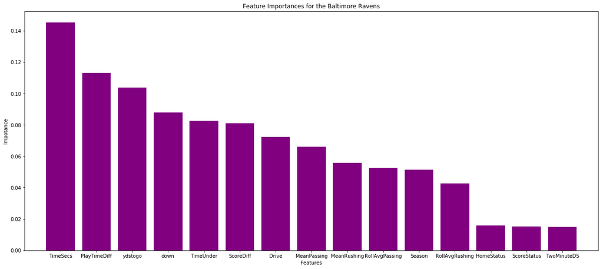

```python
importance = importance.reset_index()

# Plotting the feature importances of the random forest
plt.figure(figsize=(21, 9))
plt.title("Feature Importances for the Baltimore Ravens")
plt.bar(range(15), importance['Importance'], color="Purple", align="center")
plt.xticks(range(15), importance['Feature'])
plt.xlim([-1,15])

# Labeling the plot
plt.xlabel("Features")
plt.ylabel("Impotance")

plt.show()
```

#### Cincinnati Bengals

```python
coefs = log_regression_CIN.coef_[0]
top = np.argpartition(coefs, -15)[-15:]
top_sorted = top[np.argsort(coefs[top])]
top_sorted = top_sorted[::-1]

for i, rank in enumerate(top_sorted):
    print("Rank: ", i + 1, "\tPredictor Number: ", rank, "\tPredictor: ", plays_predictors[rank])
```

```
Rank:  1 	Predictor Number:  0 	Predictor:  down
Rank:  2 	Predictor Number:  14 	Predictor:  TwoMinuteDS
Rank:  3 	Predictor Number:  1 	Predictor:  ydstogo
Rank:  4 	Predictor Number:  10 	Predictor:  RollAvgPassing
Rank:  5 	Predictor Number:  7 	Predictor:  MeanRushing
Rank:  6 	Predictor Number:  11 	Predictor:  HomeStatus
Rank:  7 	Predictor Number:  2 	Predictor:  Drive
Rank:  8 	Predictor Number:  6 	Predictor:  PlayTimeDiff
Rank:  9 	Predictor Number:  8 	Predictor:  MeanPassing
Rank:  10 	Predictor Number:  4 	Predictor:  TimeSecs
Rank:  11 	Predictor Number:  3 	Predictor:  Season
Rank:  12 	Predictor Number:  5 	Predictor:  TimeUnder
Rank:  13 	Predictor Number:  9 	Predictor:  RollAvgRushing
Rank:  14 	Predictor Number:  12 	Predictor:  ScoreDiff
Rank:  15 	Predictor Number:  13 	Predictor:  ScoreStatus
```

#### Cleveland Browns

```python
# Placing importances into DataFrame
importances = pd.DataFrame({'Feature': X_train_CLE.columns,
                            'Importance':np.round(random_forest_CLE.feature_importances_, 4)})
importances = importances.sort_values('Importance', ascending=False).set_index('Feature')
print(importances)
```

```
                Importance
Feature
TimeSecs            0.1439
PlayTimeDiff        0.1155
ydstogo             0.0914
TimeUnder           0.0838
down                0.0834
ScoreDiff           0.0833
Drive               0.0761
MeanPassing         0.0663
MeanRushing         0.0582
RollAvgPassing      0.0556
Season              0.0515
RollAvgRushing      0.0470
HomeStatus          0.0172
TwoMinuteDS         0.0138
ScoreStatus         0.0131
```

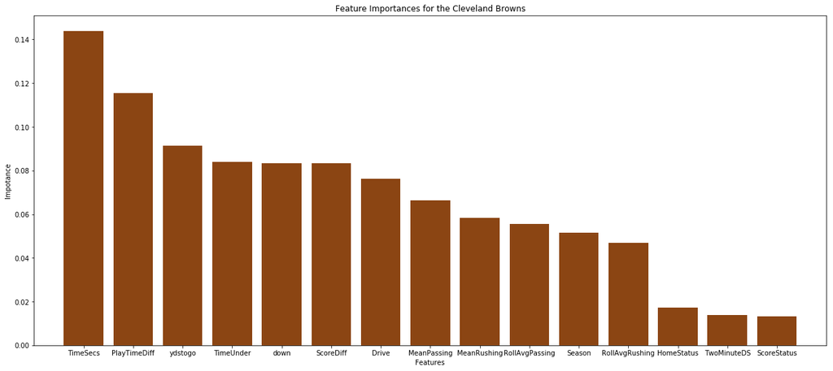

```python
importances = importances.reset_index()

# Plotting the feature importances of the random forest
plt.figure(figsize=(21, 9))
plt.title("Feature Importances for the Cleveland Browns")
plt.bar(range(15), importances['Importance'], color="saddlebrown", align="center")
plt.xticks(range(15), importances['Feature'])
plt.xlim([-1,15])

# Labeling the plot
plt.xlabel("Features")
plt.ylabel("Impotance")

plt.show()
```

#### Pittsburgh Steelers

```python
coefs = log_regression_PIT.coef_[0]
top = np.argpartition(coefs, -15)[-15:]
top_sorted = top[np.argsort(coefs[top])]
top_sorted = top_sorted[::-1]

for i, rank in enumerate(top_sorted):
    print("Rank: ", i + 1, "\tPredictor Number: ", rank, "\tPredictor: ", plays_predictors[rank])
```

```
Rank:  1 	Predictor Number:  0 	Predictor:  down
Rank:  2 	Predictor Number:  14 	Predictor:  TwoMinuteDS
Rank:  3 	Predictor Number:  11 	Predictor:  HomeStatus
Rank:  4 	Predictor Number:  1 	Predictor:  ydstogo
Rank:  5 	Predictor Number:  10 	Predictor:  RollAvgPassing
Rank:  6 	Predictor Number:  13 	Predictor:  ScoreStatus
Rank:  7 	Predictor Number:  8 	Predictor:  MeanPassing
Rank:  8 	Predictor Number:  4 	Predictor:  TimeSecs
Rank:  9 	Predictor Number:  3 	Predictor:  Season
Rank:  10 	Predictor Number:  6 	Predictor:  PlayTimeDiff
Rank:  11 	Predictor Number:  2 	Predictor:  Drive
Rank:  12 	Predictor Number:  7 	Predictor:  MeanRushing
Rank:  13 	Predictor Number:  5 	Predictor:  TimeUnder
Rank:  14 	Predictor Number:  9 	Predictor:  RollAvgRushing
Rank:  15 	Predictor Number:  12 	Predictor:  ScoreDiff
```

## Conclusion

It appears we should use Random Forest to predict whether the offensive play will be a passing play or rushing play for the Baltimore Ravens and the Cleveland Browns. In contrast, we should use Logistic Regression to predict the offensive play for the Cincinnati Bengals and the Pittsburgh Steelers. This also confirms that we should have treated each team as a separate entity instead of grouping.

For the Baltimore Ravens, the most important features were `TimeSecs`; the time remaining in the game, `PlayTimeDiff`; the time difference in between plays, and `ydstogo`; the yards to go for a first down. The fourth and fifth most important features were `down`; the down of the given play and `TimeUnder`; the time remaining in the half. The Cleveland Browns experienced very similar levels of importance for its Random Forest.

Three of these features are time-based in `TimeSecs`, `PlayTimeDiff`, and `TimeUnder`. The other two are yards-based in `ydstogo` and `down`. This signifies the relationship between time and offensive play, as well as field position and offensive play.

For the Baltimore Ravens and the Cleveland Browns, it appears our newly added features did not significantly affect the determination of whether an offensive play would be a passing play or rushing play. `RollAvgPassing` and `RollAvgRushing` all placed on the lower end of importance in comparison to the already given features. I was surprised to see that `HomeStatus`, `ScoreStatus`, and the `TwoMinuteDS` were the three lowest ranked features. I had anticipated a relationship between the current score and offensive play.

For the Cincinnati Bengals, the top five features in terms of importance were `down`, `TwoMinuteDS`, `ydstogo`, and `RollAvgPassing`, and `MeanRushing`. Similarly, for the Pittsburgh Steelers, the top five features in terms of importance were `down`, `TwoMinuteDS`, `HomeStatus`, `ydstogo`, and `RollAvgPassing`.

In contrast to the first two teams, our newly added features did seem to significantly affect the upcoming offensive play. The `TwoMinuteDS` feature, which describes a team with possession of the football in the final two minutes of the game and are currently losing or tying seems to play a noticeable role in the selection of a passing or rushing play. Whether the team is losing in the final two minutes of either half appears to play a major role in the team's play calling. The inclusion of `RollAvgPassing` also demonstrates how the offensive tendencies from the head coaches of both teams play a large factor into the play calling.

It appears a Cincinnati Bengals play call of a pass or rush can be attributed in part to `MeanRushing`, meaning that team also tends to weigh its relative performance in rushing when deciding the playcall. A Pittsburgh Steelers play call can be predicted in part due to their `HomeStatus`, meaning whether or not the team is currently playing at their home stadium.

Further analysis can be done with other teams in the NFL to contrast the results of this tutorial. It might be interesting to see if the same features appear with other teams or whether the AFC North division is a unique group.

Thank you for reading this notebook tutorial!